# Prosper Loans Exploration

## Preliminary Wrangling

> This document explores a dataset containing prosper loans and attributes for apporximately 114000 prosper loans

```python
# import all packages and set plots to be embedded inline
import numpy as np
import pandas as pd
import matplotlib.pyplot as plt
import seaborn as sb
%matplotlib inline
```

```python
#load the data
df = pd.read_csv('prosperLoanData.csv')
```

```python
# high-level overview of data shape and composition
print(df.shape)
print(df.dtypes)
```

```
(113937, 81)
ListingKey                      object
ListingNumber                    int64
ListingCreationDate             object
CreditGrade                     object
Term                             int64
                                ...
PercentFunded                  float64
Recommendations                  int64
InvestmentFromFriendsCount       int64
InvestmentFromFriendsAmount    float64
Investors                        int64
Length: 81, dtype: object
```

```python
df.head(10)
```

|  | ListingKey | ListingNumber | ListingCreationDate | CreditGrade | Term | LoanStatus | ClosedDate | BorrowerAPR | BorrowerRate | LenderYield | ... | LP_ServiceFees | LP_CollectionFees | LP_GrossPrincipalLoss | LP_NetPrincipalLoss | LP_NonPrincipalRecoverypayments | PercentFunded | Recommendations | InvestmentFromFriendsCount | InvestmentFromFriendsAmount | Investors |
| --- | --- | --- | --- | --- | --- | --- | --- | --- | --- | --- | --- | --- | --- | --- | --- | --- | --- | --- | --- | --- | --- |
| 0 | 1021339766868145413AB3B | 193129 | 2007-08-26 19:09:29.263000000 | C | 36 | Completed | 2009-08-14 00:00:00 | 0.16516 | 0.1580 | 0.1380 | ... | -133.18 | 0.0 | 0.0 | 0.0 | 0.0 | 1.0 | 0 | 0 | 0.0 | 258 |
| 1 | 10273602499503308B223C1 | 1209647 | 2014-02-27 08:28:07.900000000 | NaN | 36 | Current | NaN | 0.12016 | 0.0920 | 0.0820 | ... | 0.00 | 0.0 | 0.0 | 0.0 | 0.0 | 1.0 | 0 | 0 | 0.0 | 1 |
| 2 | 0EE9337825851032864889A | 81716 | 2007-01-05 15:00:47.090000000 | HR | 36 | Completed | 2009-12-17 00:00:00 | 0.28269 | 0.2750 | 0.2400 | ... | -24.20 | 0.0 | 0.0 | 0.0 | 0.0 | 1.0 | 0 | 0 | 0.0 | 41 |
| 3 | 0EF5356002482715299901A | 658116 | 2012-10-22 11:02:35.010000000 | NaN | 36 | Current | NaN | 0.12528 | 0.0974 | 0.0874 | ... | -108.01 | 0.0 | 0.0 | 0.0 | 0.0 | 1.0 | 0 | 0 | 0.0 | 158 |
| 4 | 0F023589499656230C5E3E2 | 909464 | 2013-09-14 18:38:39.097000000 | NaN | 36 | Current | NaN | 0.24614 | 0.2085 | 0.1985 | ... | -60.27 | 0.0 | 0.0 | 0.0 | 0.0 | 1.0 | 0 | 0 | 0.0 | 20 |
| 5 | 0F05359734824199381F61D | 1074836 | 2013-12-14 08:26:37.093000000 | NaN | 60 | Current | NaN | 0.15425 | 0.1314 | 0.1214 | ... | -25.33 | 0.0 | 0.0 | 0.0 | 0.0 | 1.0 | 0 | 0 | 0.0 | 1 |
| 6 | 0F0A3576754255009D63151 | 750899 | 2013-04-12 09:52:56.147000000 | NaN | 36 | Current | NaN | 0.31032 | 0.2712 | 0.2612 | ... | -22.95 | 0.0 | 0.0 | 0.0 | 0.0 | 1.0 | 0 | 0 | 0.0 | 1 |
| 7 | 0F1035772717087366F9EA7 | 768193 | 2013-05-05 06:49:27.493000000 | NaN | 36 | Current | NaN | 0.23939 | 0.2019 | 0.1919 | ... | -69.21 | 0.0 | 0.0 | 0.0 | 0.0 | 1.0 | 0 | 0 | 0.0 | 1 |
| 8 | 0F043596202561788EA13D5 | 1023355 | 2013-12-02 10:43:39.117000000 | NaN | 36 | Current | NaN | 0.07620 | 0.0629 | 0.0529 | ... | -16.77 | 0.0 | 0.0 | 0.0 | 0.0 | 1.0 | 0 | 0 | 0.0 | 1 |
| 9 | 0F043596202561788EA13D5 | 1023355 | 2013-12-02 10:43:39.117000000 | NaN | 36 | Current | NaN | 0.07620 | 0.0629 | 0.0529 | ... | -16.77 | 0.0 | 0.0 | 0.0 | 0.0 | 1.0 | 0 | 0 | 0.0 | 1 |

10 rows × 81 columns

```python
#Selceting the features of interests
df = df[['Term','BorrowerRate','ProsperRating (Alpha)','EmploymentStatus','EmploymentStatusDuration','LoanOriginalAmount','MonthlyLoanPayment']]
```

```python
df.head()
```

|  | Term | BorrowerRate | ProsperRating (Alpha) | EmploymentStatus | EmploymentStatusDuration | LoanOriginalAmount | MonthlyLoanPayment |
| --- | --- | --- | --- | --- | --- | --- | --- |
| 0 | 36 | 0.1580 | NaN | Self-employed | 2.0 | 9425 | 330.43 |
| 1 | 36 | 0.0920 | A | Employed | 44.0 | 10000 | 318.93 |
| 2 | 36 | 0.2750 | NaN | Not available | NaN | 3001 | 123.32 |
| 3 | 36 | 0.0974 | A | Employed | 113.0 | 10000 | 321.45 |
| 4 | 36 | 0.2085 | D | Employed | 44.0 | 15000 | 563.97 |

```python
df.info()
```

```
<class 'pandas.core.frame.DataFrame'>
RangeIndex: 113937 entries, 0 to 113936
Data columns (total 7 columns):
 #   Column                    Non-Null Count   Dtype
---  ------                    --------------   -----
 0   Term                      113937 non-null  int64
 1   BorrowerRate              113937 non-null  float64
 2   ProsperRating (Alpha)     84853 non-null   object
 3   EmploymentStatus          111682 non-null  object
 4   EmploymentStatusDuration  106312 non-null  float64
 5   LoanOriginalAmount        113937 non-null  int64
 6   MonthlyLoanPayment        113937 non-null  float64
dtypes: float64(3), int64(2), object(2)
memory usage: 6.1+ MB
```

```python
#convert prosper rating into ordered categorical types
rating = ['AA','A','B','C','D','E','HR']
rating = pd.api.types.CategoricalDtype(ordered = True, categories = rating )
df['ProsperRating (Alpha)'] = df['ProsperRating (Alpha)'].astype(rating)
```

```python
status = ['Full-time','Part-time','Employed','Self-employed','Retired','Other','Not employed','Not available']
status = pd.api.types.CategoricalDtype(ordered = True, categories = status )
df['EmploymentStatus'] = df['EmploymentStatus'].astype(status)
```

### What is the structure of your dataset?

> There are 113,937 loans in the dataset with 81 features.

### What is/are the main feature(s) of interest in your dataset?

> I am most interesed in what features can affect Borrower Rate for the loan

### What features in the dataset do you think will help support your investigation into your feature(s) of interest?

> I expect the higher the loan term is the higher the rate, also I think that the original amount and the monthly payment are a huge factor in the determinig the rate

## Univariate Exploration

> I'll start by looking at the distribution of the main variable of interest: Borrower Rate.

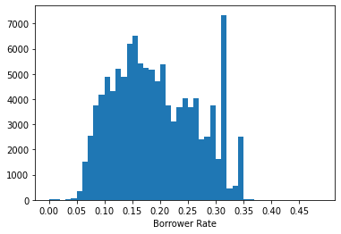

```python
bins = np.arange( df['BorrowerRate'].min() , df['BorrowerRate'].max() , 0.01 )
color = sb.color_palette()[0]
plt.hist(data=df,x='BorrowerRate',bins = bins , color = color );
x = np.arange(0,0.5,0.05)
plt.xticks(x);
plt.xlabel('Borrower Rate');
```

the distribution of Borrower Rate is multimodal with peak around 0.17 with a spike at 0.3.

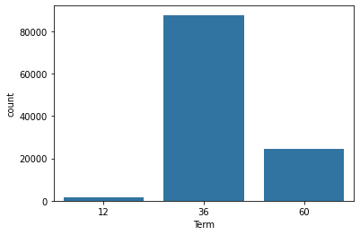

```python
sb.countplot(data= df , x ='Term', color = color);
```

Most of Borrowers prefer to get their loan on 36 months period

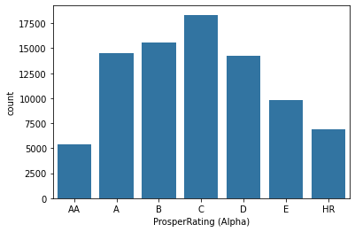

```python
sb.countplot(data=df,x='ProsperRating (Alpha)',color = color);
```

Most prosper loans of Rating C and the least loans of Rating AA which is the highest rating

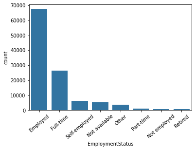

```python
order = df['EmploymentStatus'].value_counts().index
sb.countplot(data=df,x='EmploymentStatus',color = color,order=order);
plt.xticks(rotation=40);
```

Most of Borrower are Employed and Full time

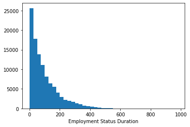

```python
bins = np.arange(0,1000,25)
plt.hist(data= df , x ='EmploymentStatusDuration',bins = bins);
plt.xlabel('Employment Status Duration');
```

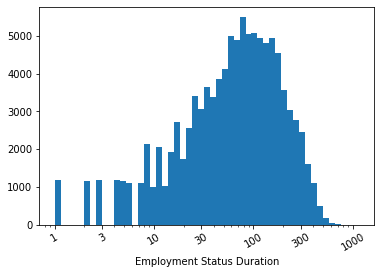

```python
bins = bins = 10 ** np.arange(0, 3+0.1, 0.06)
plt.hist(data= df , x ='EmploymentStatusDuration',bins = bins);
plt.xticks(rotation = 30);
plt.xscale('log')
ticks = [1, 3, 10, 30, 100, 300, 1000]
labels = ['{}'.format(v) for v in ticks]
plt.xticks(ticks,labels);
plt.xlabel('Employment Status Duration');
```

Employment Status Duration is right skewed, Most of Borrower have less than 200 Month of work experience, When plotted on a log-scale, the shape becomes normally ditributed around 100 which is the mean.

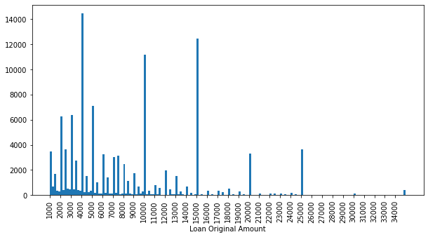

```python
plt.figure(figsize=[10,5])
bins = np.arange(1000,df['LoanOriginalAmount'].max()+200,200)
plt.hist(data=df , x='LoanOriginalAmount',bins = bins);
plt.xticks(np.arange(1000,35000,1000),rotation = 90);
plt.xlabel('Loan Original Amount');
```

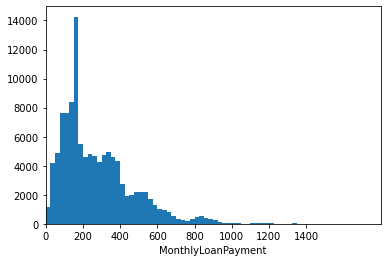

```python
bins = np.arange(0,df['MonthlyLoanPayment'].max()+25,25)
plt.hist(data=df , x='MonthlyLoanPayment',bins = bins);
plt.xticks(np.arange(0,1500,200));
plt.xlim(0,1800);
plt.xlabel('MonthlyLoanPayment');
```

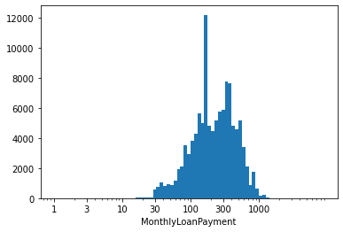

```python
bins = 10 ** np.arange(0,4,0.05)
plt.hist(data=df , x='MonthlyLoanPayment',bins = bins);
plt.xscale('log')
ticks = [1, 3, 10, 30, 100, 300, 1000]
labels = ['{}'.format(v) for v in ticks]
plt.xticks(ticks,labels);
plt.xlabel('MonthlyLoanPayment');
```

The distribution is more likely to be right skewed and most of borrowers pay less than 400 per Month. When plotted on a log scale we can find that there is a large spike around 200.

### Discuss the distribution(s) of your variable(s) of interest. Were there any unusual points? Did you need to perform any transformations?

> The distribution of Borrower Rate looks bimodal and Most of the values are between 0.25 and 0.1, There is no need to perform any additional transforamtion.

### Of the features you investigated, were there any unusual distributions? Did you perform any operations on the data to tidy, adjust, or change the form of the data? If so, why did you do this?

> The Employment status duration and monthly loan payment is right skewed. The least Porsper loan rating is AA which we can suppose of their high value. There is no need to perform any tranformation

## Bivariate Exploration

> To start off with, I want to look at the pairwise correlations present between features in the data.

```python
numeric_vars = ['BorrowerRate', 'EmploymentStatusDuration', 'LoanOriginalAmount', 'MonthlyLoanPayment']
categoric_vars = ['Term', 'ProsperRating (Alpha)', 'EmploymentStatus']
```

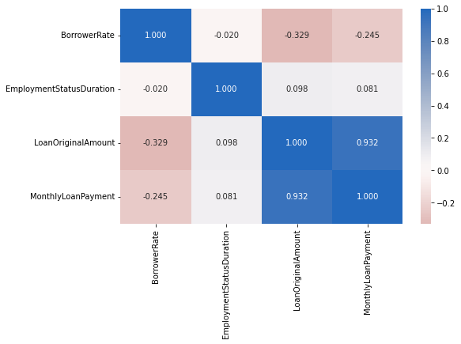

```python
# correlation plot
plt.figure(figsize = [8, 5])
sb.heatmap(df[numeric_vars].corr(), annot = True, fmt = '.3f',
           cmap = 'vlag_r', center = 0)
plt.show()
```

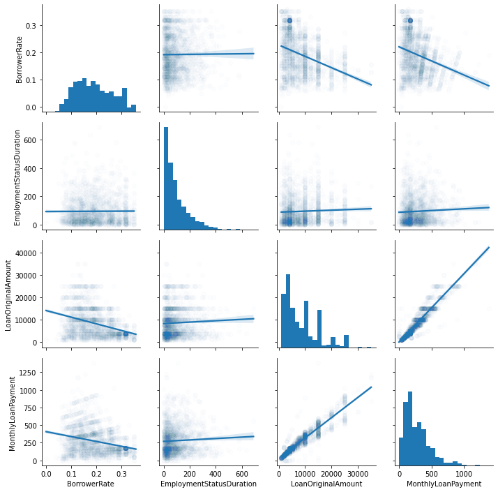

```python
#Using samples will make the plot clearer
samples = np.random.choice(df.shape[0], 2000, replace = False)
sample = df.loc[samples,:]

g = sb.PairGrid(data = sample , vars = numeric_vars)
g = g.map_diag(plt.hist, bins = 20);
g.map_offdiag(sb.regplot ,scatter_kws={'alpha':0.01});
```

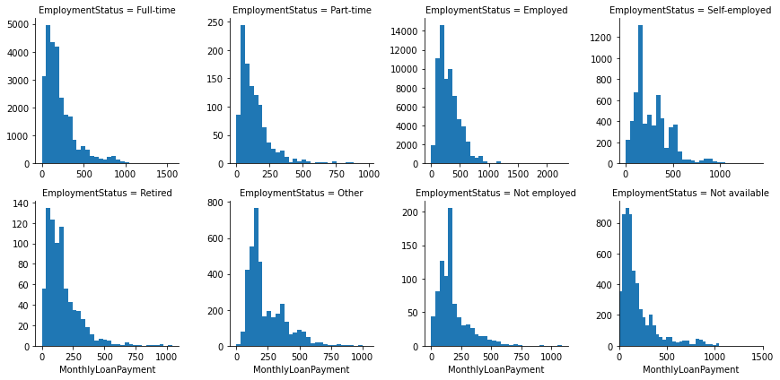

```python
x = sb.FacetGrid(data=df,col='EmploymentStatus',col_wrap=4,sharey=False,sharex=False)
x.map(plt.hist,'MonthlyLoanPayment',bins=30);
plt.xlim(0,1500);
```

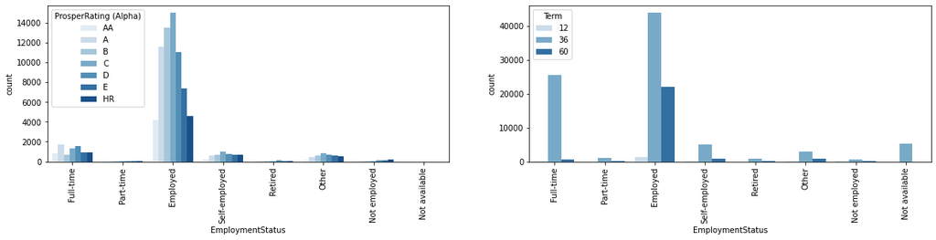

```python
plt.figure(figsize=(20,8))
plt.subplot(2,2,1);
sb.countplot(data=df,x='EmploymentStatus',hue='ProsperRating (Alpha)', palette = 'Blues')
plt.xticks(rotation=90);
plt.subplot(2,2,2);
sb.countplot(data=df,x='EmploymentStatus',hue='Term', palette = 'Blues')
plt.xticks(rotation=90);
```

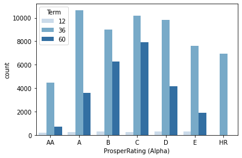

```python
sb.countplot(data=df,x='ProsperRating (Alpha)',hue='Term', palette = 'Blues');
```

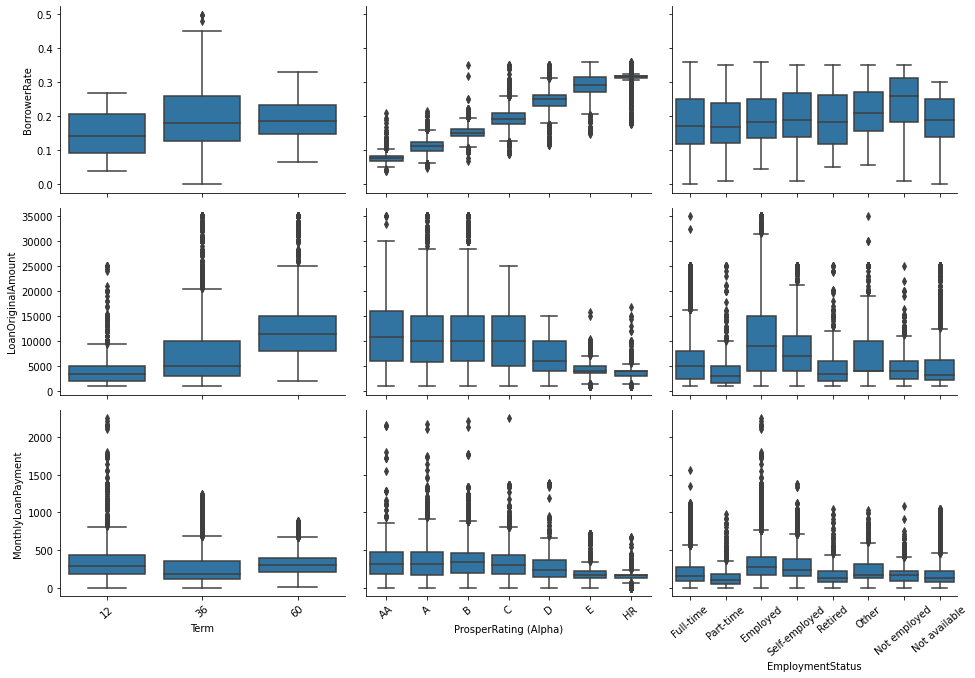

```python
def boxgrid(x, y, **kwargs):
    """ Quick hack for creating box plots with seaborn's PairGrid. """
    default_color = sb.color_palette()[0]
    sb.boxplot(x, y, color = default_color)
    plt.xticks(rotation=40)

plt.figure(figsize = [10, 10])
g = sb.PairGrid(data = df, y_vars = ['BorrowerRate', 'LoanOriginalAmount','MonthlyLoanPayment'], x_vars = categoric_vars,
                size = 3, aspect = 1.5)
g.map(boxgrid)
plt.show();
```

The figures show that the Term does not have that huge effect on the the Borrower Rate unlike the prosper rating as it is obvious we move from the best rate to the lowes rate prosper loans the Borrower rate increases. Also the Employment Status does not effect the Borrower Rate except the UnEmployment as we can see higher Borrower mean unlike different types. Seconly, We can see that the Loan Original Amount is increasing by increasing the Term and Also the better the prosper Rating the higher the Original Amount which is quite expected. Thirdly, Monthly Loan Payment nearly doesnot change with different Terms and Also by different Prosper Rating Except for of the E and HR categories

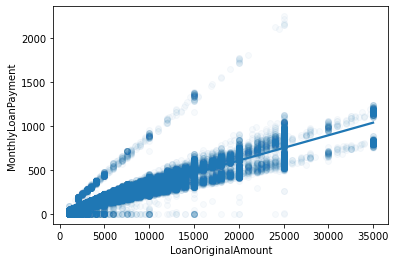

```python
sb.regplot (data=df,x = 'LoanOriginalAmount' ,y = 'MonthlyLoanPayment', scatter_kws={'alpha':0.03 } );
```

The Figure shows a directly proportinal correlation between the Monthly Loan Payment and Original Amount, The Higher the Original Amount the higher the Loan Payment

### Talk about some of the relationships you observed in this part of the investigation. How did the feature(s) of interest vary with other features in the dataset?

> The Borrower Rate is inversly proportional to the Loan Original Amount and Monthly Loan Payment which was expected but what is intersting is the Employment Satatus Duration as it does not have an effect on the Borrower Rate as the correlation coeffient is 0.02 Also the Borrower Rate increases with the lower prosper ratings, But the most intersting outcome is that the term as we can see that the Borrower Rate mean for the 3 trems is so close

## Multivariate Exploration

> The main thing I want to explore in this part of the analysis is how the categorical variable play into the relationship between borrower Rate and loan original amount.

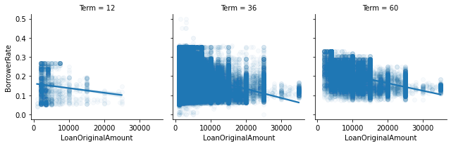

```python
plt.figure(figsize=(40,40));
x = sb.FacetGrid(  df, col='Term', margin_titles=True);
x.map(sb.regplot,'LoanOriginalAmount','BorrowerRate',scatter_kws={'alpha':0.03});
```

Term does not have any affect on the relationship between Borrower Rate and Loan Original Amount as it is always negative.

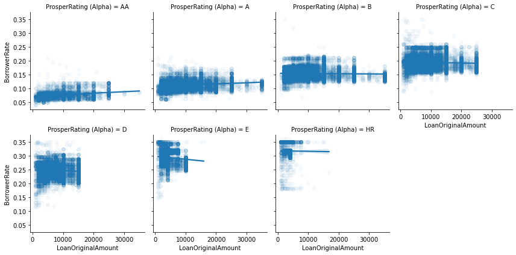

```python
plt.figure(figsize=(20,20));
x = sb.FacetGrid(  df, col='ProsperRating (Alpha)', margin_titles=True,col_wrap=4);
x.map(sb.regplot,'LoanOriginalAmount','BorrowerRate',scatter_kws={'alpha':0.03});
```

We can see that the higher Borrower Rate is of the lowest Prosper Rating and Also the higher Prosper Rating is,the higher the Loan Original Amount is, But from the fit line we can see that the relationship between the Loan Original Amount and the Borrower Rate is not that high.

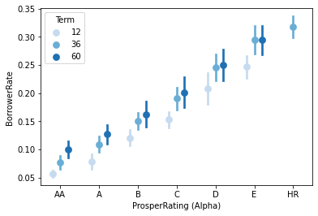

```python
g = sb.pointplot(data = df, x = 'ProsperRating (Alpha)', y = 'BorrowerRate', hue = 'Term',
           palette = 'Blues', linestyles = '', dodge = 0.4, ci='sd')
```

The figure shows that the Borrower Rate decreases with the higher Prosper Rating and the higher the term is the higher the Borrower Rate but not by far also we can see that For the E prosper rating the 36 and 60 months loans nearly have the same Borrower Rate.

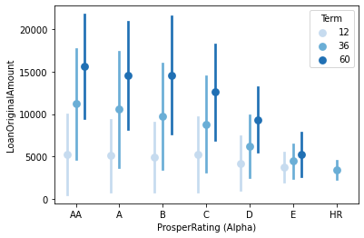

```python
g = sb.pointplot(data = df, x = 'ProsperRating (Alpha)', y = 'LoanOriginalAmount', hue = 'Term',
           palette = 'Blues', linestyles = '', dodge = 0.4, ci='sd')
```

### Talk about some of the relationships you observed in this part of the investigation. Were there features that strengthened each other in terms of looking at your feature(s) of interest?

> I am surprised that Term does not an effect on the relationship between Borrwer Rate and the Original Loan Amount, But the term has an effect on the relationship between the Borrower Rate and the prosper Rating as the higher the term the higher the rate. Also It seems that the prosper rating does not have an effect on the relationship between the Borrower Rate and the Original Amount.